# IODS course project

## Data exploration

```r
library(ggplot2)
library(dplyr)
library(tidyr)
alc_subset = select(alc, c('alc_use', 'high_use', 'sex', 'goout', 'G3', 'absences'))

gather(alc_subset) %>% glimpse()
```

```
## Rows: 2,220
## Columns: 2
## $ key   <chr> "alc_use", "alc_use", "alc_use", "alc_use", "alc_use", "alc_use"…
## $ value <chr> "1", "1", "2.5", "1", "1.5", "1.5", "1", "1", "1", "1", "1.5", "…
```

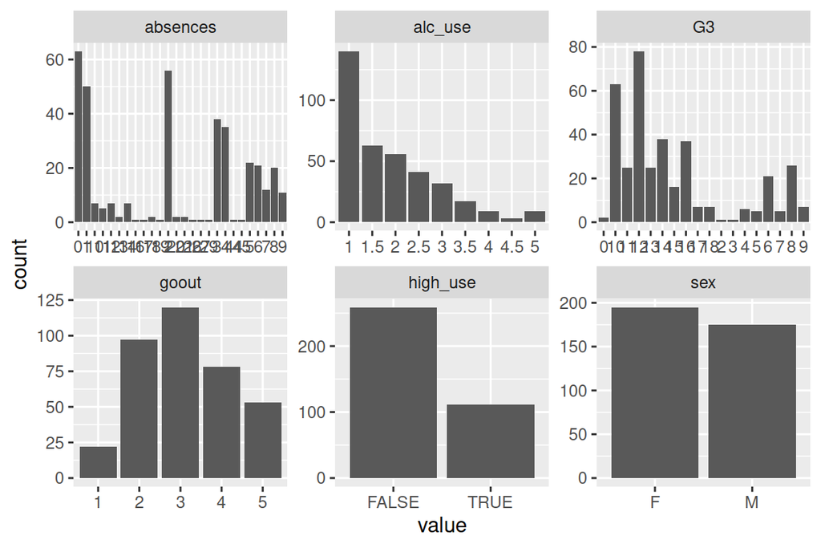

```r
gather(alc_subset) %>% View()

gather(alc_subset) %>% ggplot(aes(value)) + facet_wrap("key", scales = "free") + geom_bar()
```

```r
library(dplyr)
alc_subset %>% group_by(sex, high_use) %>% summarise(count = n())
```

[output not shown]

```
## # A tibble: 4 × 3
## # Groups:   sex [2]
##   sex   high_use count
##   <chr> <lgl>    <int>
## 1 F     FALSE      154
## 2 F     TRUE        41
## 3 M     FALSE      105
## 4 M     TRUE        70
```

Males are somewhat over represented in the high alcohol usage group, as hypothesised.

```r
alc_subset %>% group_by(sex, high_use) %>% summarise(count = n(), mean_grade = mean(G3))
```

[output not shown]

```
## # A tibble: 4 × 4
## # Groups:   sex [2]
##   sex   high_use count mean_grade
##   <chr> <lgl>    <int>      <dbl>
## 1 F     FALSE      154       11.4
## 2 F     TRUE        41       11.8
## 3 M     FALSE      105       12.3
## 4 M     TRUE        70       10.3
```

High alcohol use seems to somewhat lower the grades in males, but not in females.

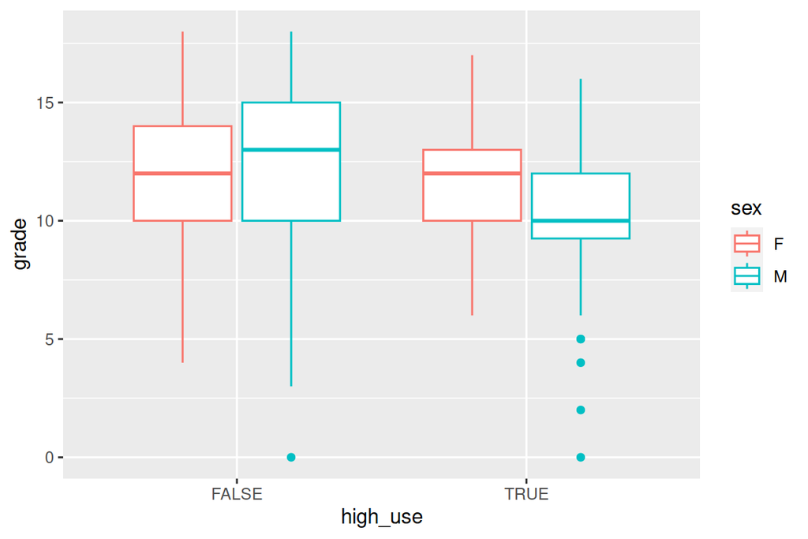

```r
# Some of the exercise code fit with my hypothesis nicely...
g1 <- ggplot(alc_subset, aes(x = high_use, y = G3))
g1 + geom_boxplot(aes(col = sex)) + ylab("grade")
```

And the same can be seen from the above plot.

```r
alc_subset %>% group_by(high_use) %>% summarise(mean_goout = mean(goout))
```

```
## # A tibble: 2 × 2
##   high_use mean_goout
##   <lgl>         <dbl>
## 1 FALSE          2.85
## 2 TRUE           3.73
```

Going out seems to quite clearly correlate with high alcohol usage, as was the hypothesis.

```r
alc_subset %>% group_by(high_use) %>% summarise(mean_absences = mean(absences))
```

```
## # A tibble: 2 × 2
##   high_use mean_absences
##   <lgl>            <dbl>
## 1 FALSE             3.71
## 2 TRUE              6.38
```

And alcohol use and absences correlate.

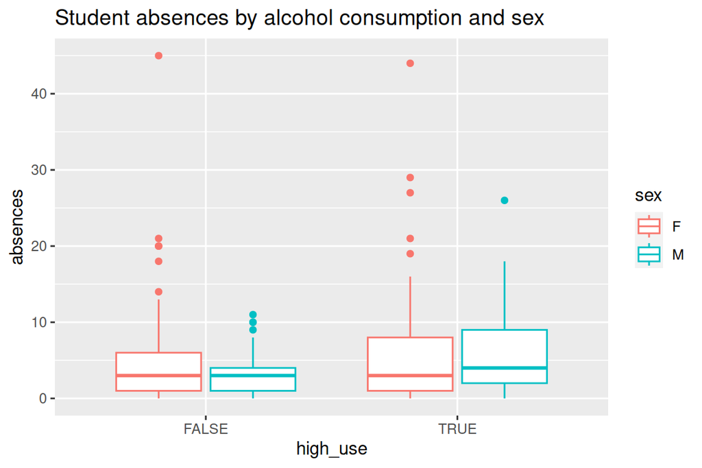

```r
g2 <- ggplot(alc_subset, aes(x = high_use, y = absences))
g2 + geom_boxplot(aes(col = sex)) + ylab("absences") +
  ggtitle("Student absences by alcohol consumption and sex")
```

But gender doesn’t seem to make a huge difference here. Still, alhocol use in males does correlate with absences more clearly.

## Logistical regression models

```r
m <- glm(high_use ~ absences + goout + sex + G3, data = alc_subset, family = "binomial")
summary(m)
```

```
##
## Call:
## glm(formula = high_use ~ absences + goout + sex + G3, family = "binomial",
##     data = alc_subset)
##
## Deviance Residuals:
##     Min       1Q   Median       3Q      Max
## -1.9500  -0.7990  -0.5263   0.8110   2.4703
##
## Coefficients:
##             Estimate Std. Error z value Pr(>|z|)
## (Intercept) -3.58037    0.70357  -5.089 3.60e-07 ***
## absences     0.08263    0.02267   3.645 0.000268 ***
## goout        0.70551    0.12167   5.799 6.68e-09 ***
## sexM         1.01859    0.25986   3.920 8.87e-05 ***
## G3          -0.04508    0.03985  -1.131 0.258029
## ---
## Signif. codes:  0 '***' 0.001 '**' 0.01 '*' 0.05 '.' 0.1 ' ' 1
##
## (Dispersion parameter for binomial family taken to be 1)
##
##     Null deviance: 452.04  on 369  degrees of freedom
## Residual deviance: 372.82  on 365  degrees of freedom
## AIC: 382.82
##
## Number of Fisher Scoring iterations: 4
```

absences, goout, and gender all strongly correlate with high_use, as demonstrated by the low p-scores, but G3 clearly does not. So, let’s drop G3 from the model:

```r
m <- glm(high_use ~ absences + goout + sex, data = alc_subset, family = "binomial")
summary(m)
```

```
##
## Call:
## glm(formula = high_use ~ absences + goout + sex, family = "binomial",
##     data = alc_subset)
##
## Deviance Residuals:
##     Min       1Q   Median       3Q      Max
## -1.8060  -0.8090  -0.5248   0.8214   2.4806
##
## Coefficients:
##             Estimate Std. Error z value Pr(>|z|)
## (Intercept) -4.18142    0.48085  -8.696  < 2e-16 ***
## absences     0.08478    0.02266   3.741 0.000183 ***
## goout        0.72793    0.12057   6.038 1.56e-09 ***
## sexM         1.02223    0.25946   3.940 8.15e-05 ***
## ---
## Signif. codes:  0 '***' 0.001 '**' 0.01 '*' 0.05 '.' 0.1 ' ' 1
##
## (Dispersion parameter for binomial family taken to be 1)
##
##     Null deviance: 452.04  on 369  degrees of freedom
## Residual deviance: 374.10  on 366  degrees of freedom
## AIC: 382.1
##
## Number of Fisher Scoring iterations: 4
```

And add coefficients and confidence intervals:

```r
OR <- coef(m) %>% exp
CI <- confint(m) %>% exp()
cbind(OR, CI)
```

```
##                    OR       2.5 %     97.5 %
## (Intercept) 0.0152768 0.005706586 0.03774415
## absences    1.0884786 1.042536998 1.14083818
## goout       2.0707952 1.644519878 2.64113883
## sexM        2.7793948 1.682230346 4.66256127
```

Alcohol consumption seem to here have a significantly lower effect on on absences, than how the results earlier seemed. But the scale for absences is a lot more granular than for the other variables here, so that might have an effect? Or maybe the effect isn’t as pronounced as on the other variables. There’s roughly 50% chance (1:1 odds) that there’s a unit change in absences if alcohol consumption state flips from high to low. For gender that chance is ~75% (2.78:1) and ~65% chance for out-goingness.

## Cross tabulation of predictions

```r
probabilities <- predict(m, type = "response")
alc_subset <- mutate(alc_subset, probability = probabilities)
alc_subset <- mutate(alc_subset, prediction = probability > 0.5)
raw_num <- table(high_use = alc_subset$high_use, prediction = alc_subset$prediction)
raw_num
```

```
##         prediction
## high_use FALSE TRUE
##    FALSE   242   17
##    TRUE     61   50
```

```r
table(high_use = alc_subset$high_use, prediction = alc_subset$prediction) %>%
  prop.table() %>%
  addmargins()
```

```
##         prediction
## high_use      FALSE       TRUE        Sum
##    FALSE 0.65405405 0.04594595 0.70000000
##    TRUE  0.16486486 0.13513514 0.30000000
##    Sum   0.81891892 0.18108108 1.00000000
```

```r
precision <- raw_num[2,2]/sum(raw_num[,2])
precision
```

```
## [1] 0.7462687
```

```r
recall <- raw_num[2,2]/sum(raw_num[2,])
recall
```

```
## [1] 0.4504505
```

```r
1 - (sum(alc_subset$high_use == alc_subset$prediction) / nrow(alc_subset))
```

```
## [1] 0.2108108
```

Total proportion of inaccurate classifications is *~21%*. That’s not too great a result. Seems like alcohol consumption does not explain all other behaviour, but still a surprisingly high number of predictions are correct. The relatively good result is probably because the model seems to err on the side of not high use, and as that is the more likely result the number of accurate predictions is misleadingly high. Precision and recall, (which were not great) are probably better indicators.

If we try predicting with the three variables we decided were significant, by predicting high alcohol consumption if at least two of the three are on the side of the indicator favoring high alcohol consumption, the results look like this:

```r
alc_subset$goout_guess <- alc_subset$goout > mean(alc_subset$goout)
alc_subset$abs_guess <- alc_subset$absences > mean(alc_subset$absences)
alc_subset$gender_guess <- alc_subset$sex == "M"
alc_subset$ultimate_guess <- (alc_subset$abs_guess + alc_subset$goout_guess + alc_subset$gender_guess) >= 2
1 - (sum(alc_subset$high_use == alc_subset$ultimate_guess) / nrow(alc_subset))
```

```
## [1] 0.2810811
```

We got 28% wrong, which is a bit higher than the model’s 21%, but not that high. I wouldn’t base students’ alcoholism intervention program on either.

# Week 4 exercises

Didn’t have time to finish these this week! Less work vfor the reviewer I guerss. I did a few of the starting points, and will finalize these later.

## The Boston dataset

```r
library(MASS)
data("Boston")
str(Boston)
```

```
## 'data.frame':    506 obs. of  14 variables:
##  $ crim   : num  0.00632 0.02731 0.02729 0.03237 0.06905 ...
##  $ zn     : num  18 0 0 0 0 0 12.5 12.5 12.5 12.5 ...
##  $ indus  : num  2.31 7.07 7.07 2.18 2.18 2.18 7.87 7.87 7.87 7.87 ...
##  $ chas   : int  0 0 0 0 0 0 0 0 0 0 ...
##  $ nox    : num  0.538 0.469 0.469 0.458 0.458 0.458 0.524 0.524 0.524 0.524 ...
##  $ rm     : num  6.58 6.42 7.18 7 7.15 ...
##  $ age    : num  65.2 78.9 61.1 45.8 54.2 58.7 66.6 96.1 100 85.9 ...
##  $ dis    : num  4.09 4.97 4.97 6.06 6.06 ...
##  $ rad    : int  1 2 2 3 3 3 5 5 5 5 ...
##  $ tax    : num  296 242 242 222 222 222 311 311 311 311 ...
##  $ ptratio: num  15.3 17.8 17.8 18.7 18.7 18.7 15.2 15.2 15.2 15.2 ...
##  $ black  : num  397 397 393 395 397 ...
##  $ lstat  : num  4.98 9.14 4.03 2.94 5.33 ...
##  $ medv   : num  24 21.6 34.7 33.4 36.2 28.7 22.9 27.1 16.5 18.9 ...
```

```r
dim(Boston)
```

```
## [1] 506  14
```

```r
summary(Boston)
```

```
##       crim                zn             indus            chas
##  Min.   : 0.00632   Min.   :  0.00   Min.   : 0.46   Min.   :0.00000
##  1st Qu.: 0.08205   1st Qu.:  0.00   1st Qu.: 5.19   1st Qu.:0.00000
##  Median : 0.25651   Median :  0.00   Median : 9.69   Median :0.00000
##  Mean   : 3.61352   Mean   : 11.36   Mean   :11.14   Mean   :0.06917
##  3rd Qu.: 3.67708   3rd Qu.: 12.50   3rd Qu.:18.10   3rd Qu.:0.00000
##  Max.   :88.97620   Max.   :100.00   Max.   :27.74   Max.   :1.00000
##       nox               rm             age              dis
##  Min.   :0.3850   Min.   :3.561   Min.   :  2.90   Min.   : 1.130
##  1st Qu.:0.4490   1st Qu.:5.886   1st Qu.: 45.02   1st Qu.: 2.100
##  Median :0.5380   Median :6.208   Median : 77.50   Median : 3.207
##  Mean   :0.5547   Mean   :6.285   Mean   : 68.57   Mean   : 3.795
##  3rd Qu.:0.6240   3rd Qu.:6.623   3rd Qu.: 94.08   3rd Qu.: 5.188
##  Max.   :0.8710   Max.   :8.780   Max.   :100.00   Max.   :12.127
##       rad              tax           ptratio          black
##  Min.   : 1.000   Min.   :187.0   Min.   :12.60   Min.   :  0.32
##  1st Qu.: 4.000   1st Qu.:279.0   1st Qu.:17.40   1st Qu.:375.38
##  Median : 5.000   Median :330.0   Median :19.05   Median :391.44
##  Mean   : 9.549   Mean   :408.2   Mean   :18.46   Mean   :356.67
##  3rd Qu.:24.000   3rd Qu.:666.0   3rd Qu.:20.20   3rd Qu.:396.23
##  Max.   :24.000   Max.   :711.0   Max.   :22.00   Max.   :396.90
##      lstat            medv
##  Min.   : 1.73   Min.   : 5.00
##  1st Qu.: 6.95   1st Qu.:17.02
##  Median :11.36   Median :21.20
##  Mean   :12.65   Mean   :22.53
##  3rd Qu.:16.95   3rd Qu.:25.00
##  Max.   :37.97   Max.   :50.00
```

The dataset has various socio-political data of Boston suburbs. The data varies from crime rates to property values and student/teacher ratios in schools.

## Dataset summary

```r
library(tidyr)
library(corrplot)
library(ggplot2)
library(GGally)

cor_matrix <- cor(Boston) %>% round(2)
cor_matrix
```

```
##          crim    zn indus  chas   nox    rm   age   dis   rad   tax ptratio
## crim     1.00 -0.20  0.41 -0.06  0.42 -0.22  0.35 -0.38  0.63  0.58    0.29
## zn      -0.20  1.00 -0.53 -0.04 -0.52  0.31 -0.57  0.66 -0.31 -0.31   -0.39
## indus    0.41 -0.53  1.00  0.06  0.76 -0.39  0.64 -0.71  0.60  0.72    0.38
## chas    -0.06 -0.04  0.06  1.00  0.09  0.09  0.09 -0.10 -0.01 -0.04   -0.12
## nox      0.42 -0.52  0.76  0.09  1.00 -0.30  0.73 -0.77  0.61  0.67    0.19
## rm      -0.22  0.31 -0.39  0.09 -0.30  1.00 -0.24  0.21 -0.21 -0.29   -0.36
## age      0.35 -0.57  0.64  0.09  0.73 -0.24  1.00 -0.75  0.46  0.51    0.26
## dis     -0.38  0.66 -0.71 -0.10 -0.77  0.21 -0.75  1.00 -0.49 -0.53   -0.23
## rad      0.63 -0.31  0.60 -0.01  0.61 -0.21  0.46 -0.49  1.00  0.91    0.46
## tax      0.58 -0.31  0.72 -0.04  0.67 -0.29  0.51 -0.53  0.91  1.00    0.46
## ptratio  0.29 -0.39  0.38 -0.12  0.19 -0.36  0.26 -0.23  0.46  0.46    1.00
## black   -0.39  0.18 -0.36  0.05 -0.38  0.13 -0.27  0.29 -0.44 -0.44   -0.18
## lstat    0.46 -0.41  0.60 -0.05  0.59 -0.61  0.60 -0.50  0.49  0.54    0.37
## medv    -0.39  0.36 -0.48  0.18 -0.43  0.70 -0.38  0.25 -0.38 -0.47   -0.51
##         black lstat  medv
## crim    -0.39  0.46 -0.39
## zn       0.18 -0.41  0.36
## indus   -0.36  0.60 -0.48
## chas     0.05 -0.05  0.18
## nox     -0.38  0.59 -0.43
## rm       0.13 -0.61  0.70
## age     -0.27  0.60 -0.38
## dis      0.29 -0.50  0.25
## rad     -0.44  0.49 -0.38
## tax     -0.44  0.54 -0.47
## ptratio -0.18  0.37 -0.51
## black    1.00 -0.37  0.33
## lstat   -0.37  1.00 -0.74
## medv     0.33 -0.74  1.00
```

[figure not shown]

```r
ggpairs(Boston)
```

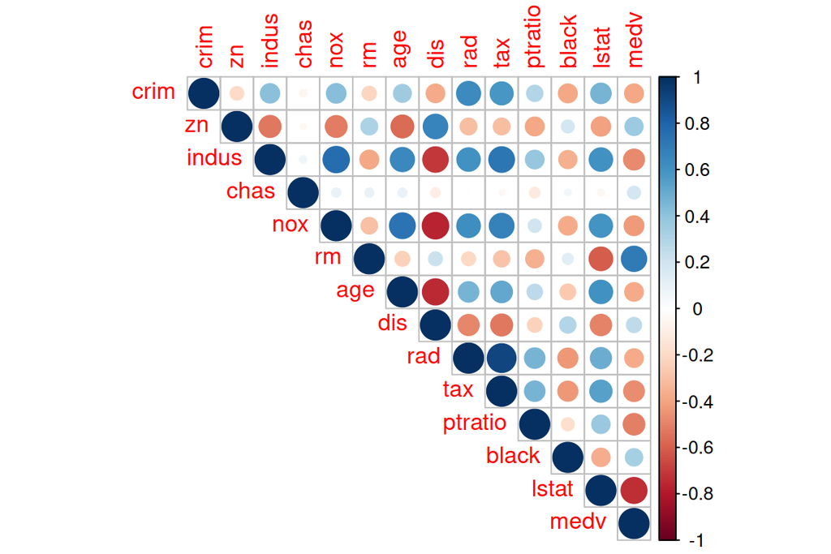

```r
corrplot(cor_matrix, method="circle", type="upper")
```

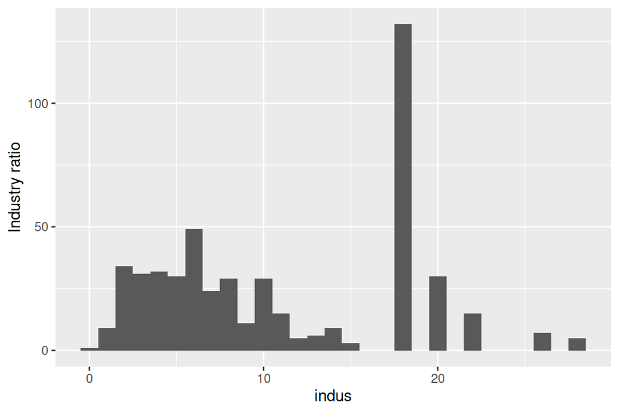

```r
Boston %>% ggplot(aes(indus)) +
  geom_histogram(binwidth = 1) +
  ylab("Industry ratio")
```

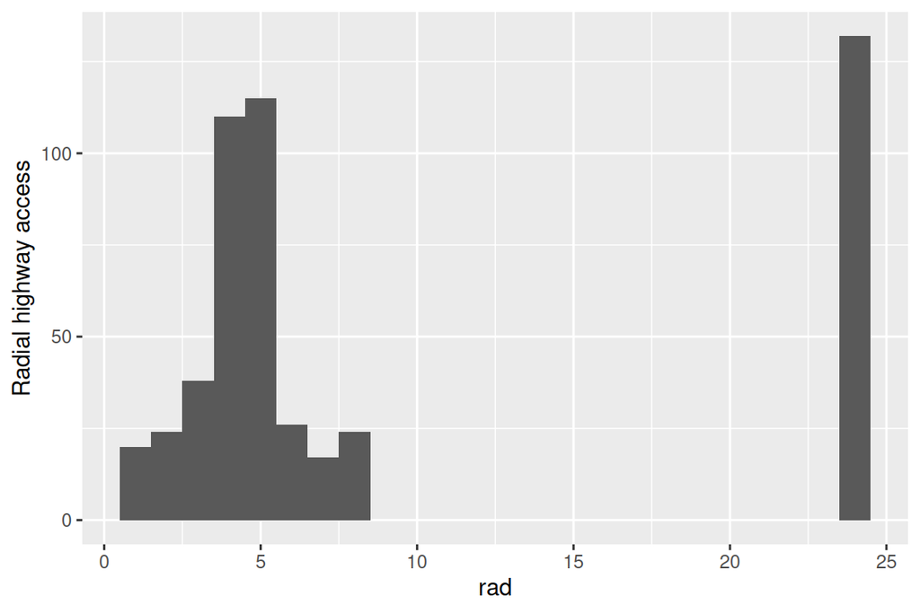

```r
Boston %>% ggplot(aes(rad)) +
  geom_histogram(binwidth = 1) +
  ylab("Radial highway access")
```

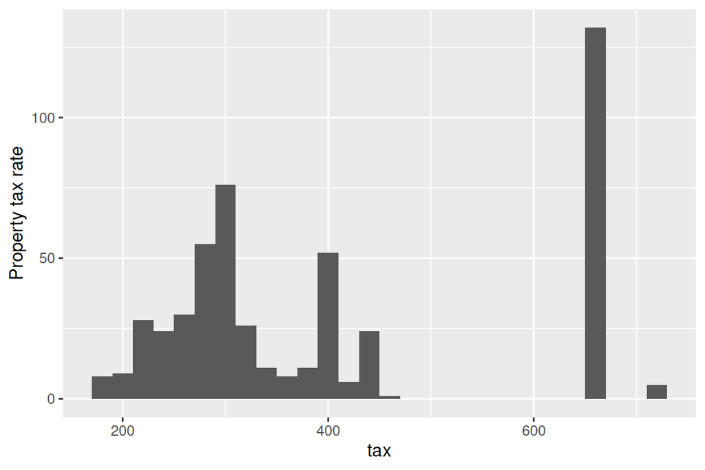

```r
Boston %>% ggplot(aes(tax)) +
  geom_histogram(binwidth = 20) +
  ylab("Property tax rate")
```

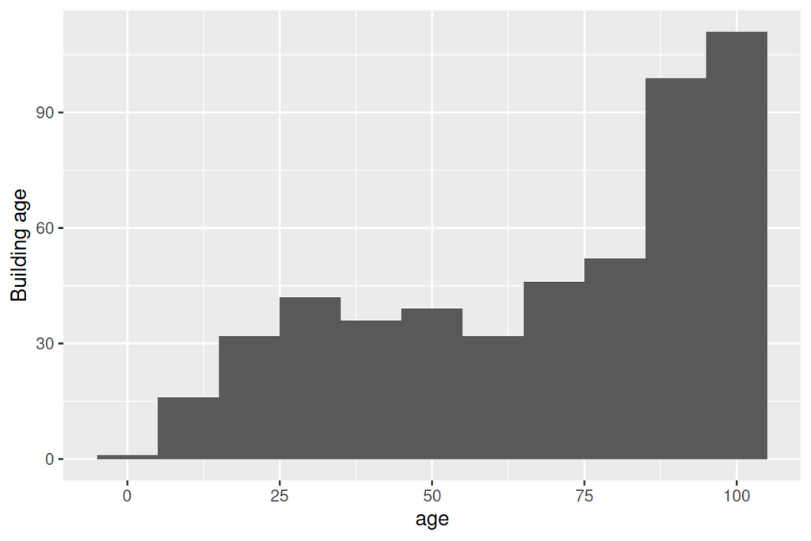

```r
Boston %>% ggplot(aes(age)) +
  geom_histogram(binwidth = 10) +
  ylab("Building age")
```

Few variables have a very strongly stratified scope. Some suburbs have very high values, most others very low. See for example crime rate (crim), river proximity (chas) and proportion of people of colour of the residents (black).

Industry rate seems to correlate (nagatively or positively) strongly with many of the other variables in the dataset. The histograms of the correlating variables vary in shape quite widely, so probably there’s quite a bit of variance in suburbs on these.

## Standardized data, training and testing sets

```r
library(dplyr)

boston_scaled <- scale(Boston) %>% as.data.frame()
boston_scaled$crim <- as.numeric(boston_scaled$crim)
summary(boston_scaled)
```

```
##       crim                 zn               indus              chas
##  Min.   :-0.419367   Min.   :-0.48724   Min.   :-1.5563   Min.   :-0.2723
##  1st Qu.:-0.410563   1st Qu.:-0.48724   1st Qu.:-0.8668   1st Qu.:-0.2723
##  Median :-0.390280   Median :-0.48724   Median :-0.2109   Median :-0.2723
##  Mean   : 0.000000   Mean   : 0.00000   Mean   : 0.0000   Mean   : 0.0000
##  3rd Qu.: 0.007389   3rd Qu.: 0.04872   3rd Qu.: 1.0150   3rd Qu.:-0.2723
##  Max.   : 9.924110   Max.   : 3.80047   Max.   : 2.4202   Max.   : 3.6648
##       nox                rm               age               dis
##  Min.   :-1.4644   Min.   :-3.8764   Min.   :-2.3331   Min.   :-1.2658
##  1st Qu.:-0.9121   1st Qu.:-0.5681   1st Qu.:-0.8366   1st Qu.:-0.8049
##  Median :-0.1441   Median :-0.1084   Median : 0.3171   Median :-0.2790
##  Mean   : 0.0000   Mean   : 0.0000   Mean   : 0.0000   Mean   : 0.0000
##  3rd Qu.: 0.5981   3rd Qu.: 0.4823   3rd Qu.: 0.9059   3rd Qu.: 0.6617
##  Max.   : 2.7296   Max.   : 3.5515   Max.   : 1.1164   Max.   : 3.9566
##       rad               tax             ptratio            black
##  Min.   :-0.9819   Min.   :-1.3127   Min.   :-2.7047   Min.   :-3.9033
##  1st Qu.:-0.6373   1st Qu.:-0.7668   1st Qu.:-0.4876   1st Qu.: 0.2049
##  Median :-0.5225   Median :-0.4642   Median : 0.2746   Median : 0.3808
##  Mean   : 0.0000   Mean   : 0.0000   Mean   : 0.0000   Mean   : 0.0000
##  3rd Qu.: 1.6596   3rd Qu.: 1.5294   3rd Qu.: 0.8058   3rd Qu.: 0.4332
##  Max.   : 1.6596   Max.   : 1.7964   Max.   : 1.6372   Max.   : 0.4406
##      lstat              medv
##  Min.   :-1.5296   Min.   :-1.9063
##  1st Qu.:-0.7986   1st Qu.:-0.5989
##  Median :-0.1811   Median :-0.1449
##  Mean   : 0.0000   Mean   : 0.0000
##  3rd Qu.: 0.6024   3rd Qu.: 0.2683
##  Max.   : 3.5453   Max.   : 2.9865
```

```r
crime <- cut(boston_scaled$crim, breaks = quantile(boston_scaled$crim), include.lowest = TRUE,
             labels = c("low", "med_low", "med_high", "high"))

boston_scaled$crim <- crime

# Create test and train datasets
n <- nrow(boston_scaled)
ind <- sample(n,  size = n * 0.8)
train <- boston_scaled[ind,]
test <- boston_scaled[-ind,]
```

All the variables were standardized with the scale() -function. The “crim” (crime rate) variable in the Boston dataset was overwritten with the standardized categorized version.

## LDA

```r
lda.fit <- lda(crim ~ ., data = train)
lda.fit
```

```
## Call:
## lda(crim ~ ., data = train)
##
## Prior probabilities of groups:
##       low   med_low  med_high      high
## 0.2599010 0.2549505 0.2326733 0.2524752
##
## Group means:
##                  zn      indus         chas        nox          rm        age
## low       1.0912510 -0.9380078 -0.084848104 -0.9210272  0.41389999 -0.9318366
## med_low  -0.0844865 -0.2503738 -0.042983423 -0.5506050 -0.17343398 -0.3163538
## med_high -0.4042228  0.1728911  0.272163518  0.4137401  0.02292898  0.4221702
## high     -0.4872402  1.0171096 -0.002135914  1.0841473 -0.42472448  0.8184986
##                 dis        rad        tax     ptratio       black       lstat
## low       0.9917022 -0.6974889 -0.7287303 -0.49283557  0.37470597 -0.75823280
## med_low   0.3576895 -0.5403247 -0.4545930 -0.04403779  0.31174403 -0.08799855
## med_high -0.3739276 -0.3990853 -0.3079246 -0.21827564  0.04046988  0.08487333
## high     -0.8468535  1.6382099  1.5141140  0.78087177 -0.83803774  0.88193011
##                 medv
## low       0.50114671
## med_low  -0.01866253
## med_high  0.07566698
## high     -0.65967722
##
## Coefficients of linear discriminants:
##                  LD1         LD2          LD3
## zn       0.087233046  0.72205127 -0.867088444
## indus   -0.009529975 -0.14831188  0.475199360
## chas    -0.068150293 -0.07679773  0.009721734
## nox      0.380160092 -0.62377403 -1.438690439
## rm      -0.137889533 -0.08321470 -0.172187825
## age      0.251112104 -0.31442954 -0.147886141
## dis     -0.088042160 -0.14801043  0.202740868
## rad      3.151448310  0.96258888  0.030124120
## tax      0.021631538  0.01922800  0.530156272
## ptratio  0.116714298 -0.04915406 -0.277337134
## black   -0.123005030  0.01372769  0.138810171
## lstat    0.216677164 -0.21162513  0.311716435
## medv     0.205931425 -0.28919551 -0.130575149
##
## Proportion of trace:
##    LD1    LD2    LD3
## 0.9478 0.0395 0.0127
```

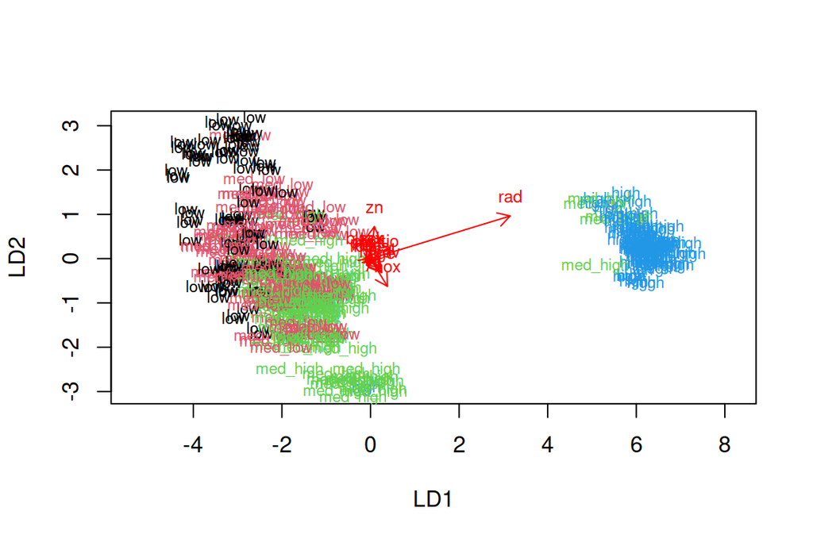

```r
lda.arrows <- function(x, myscale = 1, arrow_heads = 0.1, color = "red", tex = 0.75, choices = c(1,2)){
  heads <- coef(x)
  arrows(x0 = 0, y0 = 0,
         x1 = myscale * heads[,choices[1]],
         y1 = myscale * heads[,choices[2]], col=color, length = arrow_heads)
  text(myscale * heads[,choices], labels = row.names(heads),
       cex = tex, col=color, pos=3)
}


classes <- as.numeric(train$crim)

plot(lda.fit, dimen = 2, col = classes, pch = classes)
lda.arrows(lda.fit, myscale = 1)
```

## LDA predictions

```r
test_crime <- test$crim

test_lda <- dplyr::select(test, -crim)

lda.pred <- predict(lda.fit, newdata = test_lda)
table(correct = test$crim, predicted = lda.pred$class)
```

```
##           predicted
## correct    low med_low med_high high
##   low        8      11        3    0
##   med_low    5      13        5    0
##   med_high   0       6       25    1
##   high       0       0        0   25
```

## K-means (unfinished)

```r
boston_scaled <- scale(Boston) %>% as.data.frame()
```

Reload the Boston dataset and standardize the dataset (we did not do this in the Exercise Set, but you should scale the variables to get comparable distances). Calculate the distances between the observations. Run k-means algorithm on the dataset. Investigate what is the optimal number of clusters and run the algorithm again. Visualize the clusters (for example with the pairs() or ggpairs() functions, where the clusters are separated with colors) and interpret the results. (0-4 points)

# Week 5 exercises

## Data summary

```r
human <- read.table(file = "data/human.csv", row.names = 1, sep = ",", header = TRUE)
summary(human)
```

```
##     Edu2.FM          Labo.FM          Edu.Exp         Life.Exp
##  Min.   :0.1717   Min.   :0.1857   Min.   : 5.40   Min.   :49.00
##  1st Qu.:0.7264   1st Qu.:0.5984   1st Qu.:11.25   1st Qu.:66.30
##  Median :0.9375   Median :0.7535   Median :13.50   Median :74.20
##  Mean   :0.8529   Mean   :0.7074   Mean   :13.18   Mean   :71.65
##  3rd Qu.:0.9968   3rd Qu.:0.8535   3rd Qu.:15.20   3rd Qu.:77.25
##  Max.   :1.4967   Max.   :1.0380   Max.   :20.20   Max.   :83.50
##       GNI            Mat.Mor         Ado.Birth         Parli.F
##  Min.   :   581   Min.   :   1.0   Min.   :  0.60   Min.   : 0.00
##  1st Qu.:  4198   1st Qu.:  11.5   1st Qu.: 12.65   1st Qu.:12.40
##  Median : 12040   Median :  49.0   Median : 33.60   Median :19.30
##  Mean   : 17628   Mean   : 149.1   Mean   : 47.16   Mean   :20.91
##  3rd Qu.: 24512   3rd Qu.: 190.0   3rd Qu.: 71.95   3rd Qu.:27.95
##  Max.   :123124   Max.   :1100.0   Max.   :204.80   Max.   :57.50
```

```r
library(tidyr)
library(corrplot)
library(ggplot2)
library(GGally)

cor_matrix <- cor(human) %>% round(2)
cor_matrix
```

```
##           Edu2.FM Labo.FM Edu.Exp Life.Exp   GNI Mat.Mor Ado.Birth Parli.F
## Edu2.FM      1.00    0.01    0.59     0.58  0.43   -0.66     -0.53    0.08
## Labo.FM      0.01    1.00    0.05    -0.14 -0.02    0.24      0.12    0.25
## Edu.Exp      0.59    0.05    1.00     0.79  0.62   -0.74     -0.70    0.21
## Life.Exp     0.58   -0.14    0.79     1.00  0.63   -0.86     -0.73    0.17
## GNI          0.43   -0.02    0.62     0.63  1.00   -0.50     -0.56    0.09
## Mat.Mor     -0.66    0.24   -0.74    -0.86 -0.50    1.00      0.76   -0.09
## Ado.Birth   -0.53    0.12   -0.70    -0.73 -0.56    0.76      1.00   -0.07
## Parli.F      0.08    0.25    0.21     0.17  0.09   -0.09     -0.07    1.00
```

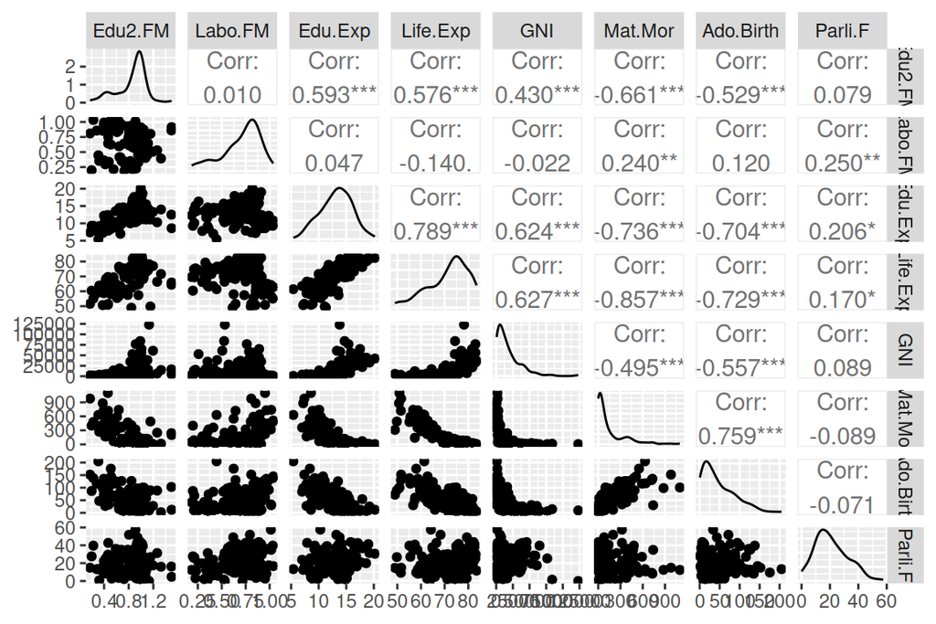

```r
ggpairs(human)
```

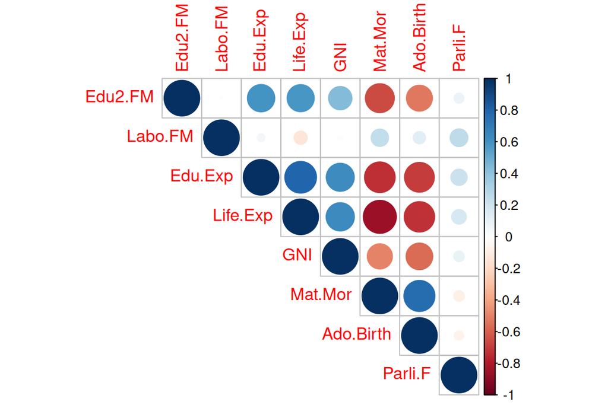

```r
corrplot(cor_matrix, method="circle", type="upper")
```

There’s quite strong correlation between many of the variables in the data. Distributions vary, but often the shapes of the distribution historgrams are similar- for example between Mat.Mor and GNI, or between Labo.FM, Edu.Exp and Life.Exp.

For refenrece, the data description from https://github.com/KimmoVehkalahti/Helsinki-Open-Data-Science/blob/master/datasets/human_meta.txt :

### Health and knowledge

“GNI” = Gross National Income per capita “Life.Exp” = Life expectancy at birth “Edu.Exp” = Expected years of schooling “Mat.Mor” = Maternal mortality ratio “Ado.Birth” = Adolescent birth rate

### Empowerment

“Parli.F” = Percetange of female representatives in parliament “Edu2.F” = Proportion of females with at least secondary education “Edu2.M” = Proportion of males with at least secondary education “Labo.F” = Proportion of females in the labour force “Labo.M” ” Proportion of males in the labour force

“Edu2.FM” = Edu2.F / Edu2.M “Labo.FM” = Labo2.F / Labo2.M

## PCA

### raw data

Perform principal component analysis (PCA) on the raw (non-standardized) human data. Show the variability captured by the principal components. Draw a biplot displaying the observations by the first two principal components (PC1 coordinate in x-axis, PC2 coordinate in y-axis), along with arrows representing the original variables. (0-2 points)

```r
pca_human <- prcomp(human)
pca_human
```

```
## Standard deviations (1, .., p=8):
## [1] 1.854416e+04 1.855219e+02 2.518701e+01 1.145441e+01 3.766241e+00
## [6] 1.565912e+00 1.912052e-01 1.591112e-01
##
## Rotation (n x k) = (8 x 8):
##                     PC1           PC2           PC3           PC4           PC5
## Edu2.FM   -5.607472e-06  0.0006713951 -3.412027e-05 -2.736326e-04 -0.0022935252
## Labo.FM    2.331945e-07 -0.0002819357  5.302884e-04 -4.692578e-03  0.0022190154
## Edu.Exp   -9.562910e-05  0.0075529759  1.427664e-02 -3.313505e-02  0.1431180282
## Life.Exp  -2.815823e-04  0.0283150248  1.294971e-02 -6.752684e-02  0.9865644425
## GNI       -9.999832e-01 -0.0057723054 -5.156742e-04  4.932889e-05 -0.0001135863
## Mat.Mor    5.655734e-03 -0.9916320120  1.260302e-01 -6.100534e-03  0.0266373214
## Ado.Birth  1.233961e-03 -0.1255502723 -9.918113e-01  5.301595e-03  0.0188618600
## Parli.F   -5.526460e-05  0.0032317269 -7.398331e-03 -9.971232e-01 -0.0716401914
##                     PC6           PC7           PC8
## Edu2.FM    2.180183e-02  6.998623e-01  7.139410e-01
## Labo.FM    3.264423e-02  7.132267e-01 -7.001533e-01
## Edu.Exp    9.882477e-01 -3.826887e-02  7.776451e-03
## Life.Exp  -1.453515e-01  5.380452e-03  2.281723e-03
## GNI       -2.711698e-05 -8.075191e-07 -1.176762e-06
## Mat.Mor    1.695203e-03  1.355518e-04  8.371934e-04
## Ado.Birth  1.273198e-02 -8.641234e-05 -1.707885e-04
## Parli.F   -2.309896e-02 -2.642548e-03  2.680113e-03
```

```r
summary(pca_human)
```

```
## Importance of components:
##                              PC1      PC2   PC3   PC4   PC5   PC6    PC7    PC8
## Standard deviation     1.854e+04 185.5219 25.19 11.45 3.766 1.566 0.1912 0.1591
## Proportion of Variance 9.999e-01   0.0001  0.00  0.00 0.000 0.000 0.0000 0.0000
## Cumulative Proportion  9.999e-01   1.0000  1.00  1.00 1.000 1.000 1.0000 1.0000
```

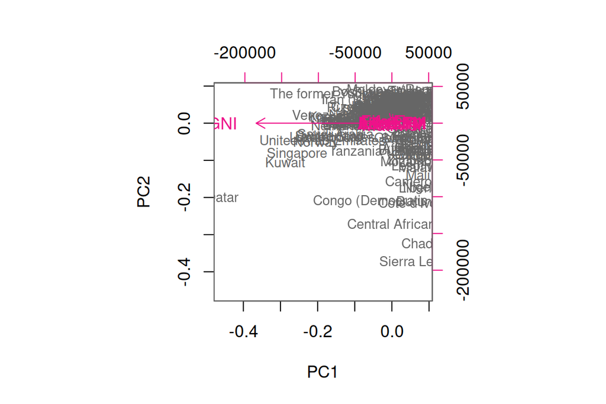

```r
biplot(pca_human, choices = 1:2, col = c("grey40", "deeppink2"), cex = c(0.8, 1))
```

### standardized data

```r
human_std <- scale(human)
pca_human_std <- prcomp(human_std)
pca_human_std
```

```
## Standard deviations (1, .., p=8):
## [1] 2.0708380 1.1397204 0.8750485 0.7788630 0.6619563 0.5363061 0.4589994
## [8] 0.3222406
##
## Rotation (n x k) = (8 x 8):
##                   PC1         PC2         PC3         PC4        PC5
## Edu2.FM   -0.35664370  0.03796058 -0.24223089 -0.62678110  0.5983585
## Labo.FM    0.05457785  0.72432726 -0.58428770 -0.06199424 -0.2625067
## Edu.Exp   -0.42766720  0.13940571 -0.07340270  0.07020294 -0.1659678
## Life.Exp  -0.44372240 -0.02530473  0.10991305  0.05834819 -0.1628935
## GNI       -0.35048295  0.05060876 -0.20168779  0.72727675  0.4950306
## Mat.Mor    0.43697098  0.14508727 -0.12522539  0.25170614  0.1800657
## Ado.Birth  0.41126010  0.07708468  0.01968243 -0.04986763  0.4672068
## Parli.F   -0.08438558  0.65136866  0.72506309 -0.01396293  0.1523699
##                   PC6         PC7         PC8
## Edu2.FM    0.17713316  0.05773644  0.16459453
## Labo.FM   -0.03500707 -0.22729927 -0.07304568
## Edu.Exp   -0.38606919  0.77962966 -0.05415984
## Life.Exp  -0.42242796 -0.43406432  0.62737008
## GNI        0.11120305 -0.13711838 -0.16961173
## Mat.Mor    0.17370039  0.35380306  0.72193946
## Ado.Birth -0.76056557 -0.06897064 -0.14335186
## Parli.F    0.13749772  0.00568387 -0.02306476
```

```r
summary(pca_human_std)
```

```
## Importance of components:
##                           PC1    PC2     PC3     PC4     PC5     PC6     PC7
## Standard deviation     2.0708 1.1397 0.87505 0.77886 0.66196 0.53631 0.45900
## Proportion of Variance 0.5361 0.1624 0.09571 0.07583 0.05477 0.03595 0.02634
## Cumulative Proportion  0.5361 0.6984 0.79413 0.86996 0.92473 0.96069 0.98702
##                            PC8
## Standard deviation     0.32224
## Proportion of Variance 0.01298
## Cumulative Proportion  1.00000
```

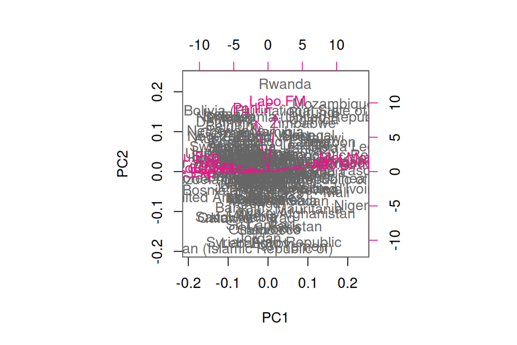

```r
biplot(pca_human_std, choices = 1:2, col = c("grey40", "deeppink2"))
```

Standardizing the variables brought their properties in the PCA much closer together. The plot of the non-standardized PCA is almost unreadable- the only variable that stands out is GNI, and that should follow from the fact that the absolute values there are way higher than in the other variables.

In the standardized version, few clear directions are discernible. Maternal mortality ratio and Adolescent birth rate clearly have similar pull, both related to births. The gender balance in labour and percentage of female representatives in parliament also have an effect in the same direction. Rest of the variables (GNI, Life expectancy at birth, Expected years of schooling and gender balance in secondary education) all form a third group.

## Tea

```r
tea <- read.csv("https://raw.githubusercontent.com/KimmoVehkalahti/Helsinki-Open-Data-Science/master/datasets/tea.csv", stringsAsFactors = TRUE)
dim(tea)
```

```
## [1] 300  36
```

```r
str(tea)
```

```
## 'data.frame':    300 obs. of  36 variables:
##  $ breakfast       : Factor w/ 2 levels "breakfast","Not.breakfast": 1 1 2 2 1 2 1 2 1 1 ...
##  $ tea.time        : Factor w/ 2 levels "Not.tea time",..: 1 1 2 1 1 1 2 2 2 1 ...
##  $ evening         : Factor w/ 2 levels "evening","Not.evening": 2 2 1 2 1 2 2 1 2 1 ...
##  $ lunch           : Factor w/ 2 levels "lunch","Not.lunch": 2 2 2 2 2 2 2 2 2 2 ...
##  $ dinner          : Factor w/ 2 levels "dinner","Not.dinner": 2 2 1 1 2 1 2 2 2 2 ...
##  $ always          : Factor w/ 2 levels "always","Not.always": 2 2 2 2 1 2 2 2 2 2 ...
##  $ home            : Factor w/ 2 levels "home","Not.home": 1 1 1 1 1 1 1 1 1 1 ...
##  $ work            : Factor w/ 2 levels "Not.work","work": 1 1 2 1 1 1 1 1 1 1 ...
##  $ tearoom         : Factor w/ 2 levels "Not.tearoom",..: 1 1 1 1 1 1 1 1 1 2 ...
##  $ friends         : Factor w/ 2 levels "friends","Not.friends": 2 2 1 2 2 2 1 2 2 2 ...
##  $ resto           : Factor w/ 2 levels "Not.resto","resto": 1 1 2 1 1 1 1 1 1 1 ...
##  $ pub             : Factor w/ 2 levels "Not.pub","pub": 1 1 1 1 1 1 1 1 1 1 ...
##  $ Tea             : Factor w/ 3 levels "black","Earl Grey",..: 1 1 2 2 2 2 2 1 2 1 ...
##  $ How             : Factor w/ 4 levels "alone","lemon",..: 1 3 1 1 1 1 1 3 3 1 ...
```

[output cut: 22 more lines]

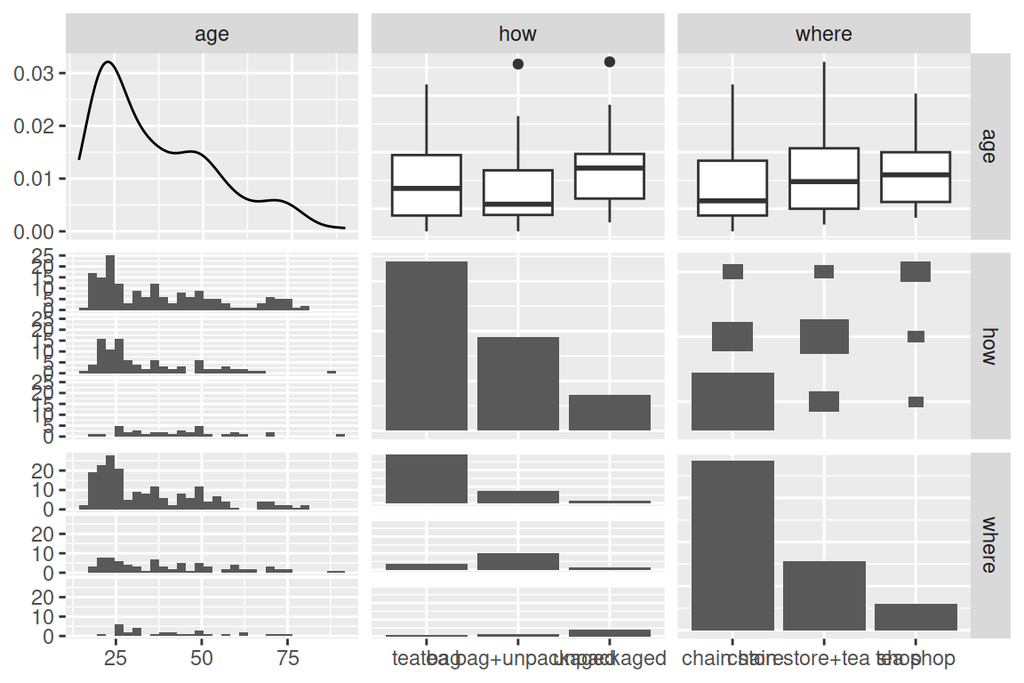

```r
ggpairs(tea[,c("age", "how", "where")])
```

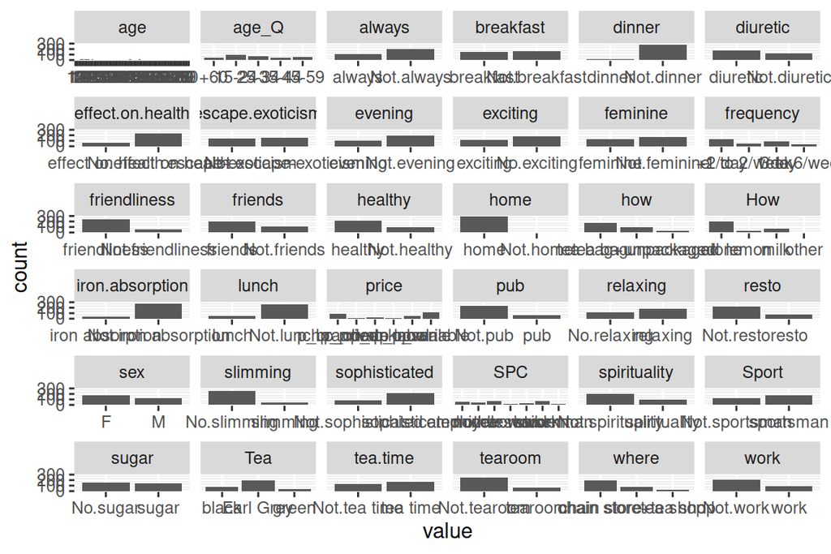

```r
ggplot(gather(tea), aes(value)) +
    geom_histogram(stat="count") +
    facet_wrap(~key, scales = 'free_x')
```

Did have a quick look at some selected correlations with ggpairs. Also histograms of all the columns.

```r
tea_subset <- tea[,c("spirituality", "healthy", "friendliness", "relaxing", "sophisticated", "exciting", "feminine")]
tea_subset$healthy <- relevel(tea_subset$healthy, "Not.healthy")
tea_subset$friendliness <- relevel(tea_subset$friendliness, "Not.friendliness")
tea_subset$exciting <- relevel(tea_subset$exciting, "No.exciting")
tea_subset$feminine <- relevel(tea_subset$feminine, "Not.feminine")

library(FactoMineR)
mca <- MCA(tea_subset, graph = FALSE)

# summary of the model
summary(mca)
```

```
##
## Call:
## MCA(X = tea_subset, graph = FALSE)
##
##
## Eigenvalues
##                        Dim.1   Dim.2   Dim.3   Dim.4   Dim.5   Dim.6   Dim.7
## Variance               0.208   0.185   0.154   0.135   0.120   0.109   0.089
## % of var.             20.786  18.492  15.444  13.509  12.033  10.880   8.856
## Cumulative % of var.  20.786  39.279  54.723  68.232  80.265  91.144 100.000
##
## Individuals (the 10 first)
##                      Dim.1    ctr   cos2    Dim.2    ctr   cos2    Dim.3    ctr
## 1                 |  0.996  1.591  0.653 | -0.211  0.080  0.029 | -0.082  0.014
## 2                 |  0.951  1.449  0.546 |  0.333  0.200  0.067 |  0.068  0.010
## 3                 |  0.375  0.225  0.174 | -0.600  0.649  0.446 | -0.219  0.103
## 4                 |  0.034  0.002  0.001 | -0.468  0.395  0.167 |  0.837  1.511
## 5                 |  0.286  0.131  0.062 | -0.314  0.178  0.074 |  0.539  0.628
## 6                 |  0.781  0.978  0.446 | -0.686  0.849  0.344 |  0.183  0.072
## 7                 |  0.781  0.978  0.446 | -0.686  0.849  0.344 |  0.183  0.072
## 8                 | -0.458  0.336  0.360 | -0.384  0.266  0.253 | -0.400  0.345
## 9                 |  0.545  0.477  0.223 | -0.284  0.146  0.061 |  0.464  0.465
## 10                |  0.375  0.225  0.174 | -0.600  0.649  0.446 | -0.219  0.103
##                     cos2
## 1                  0.004 |
## 2                  0.003 |
## 3                  0.059 |
## 4                  0.534 |
## 5                  0.219 |
## 6                  0.024 |
## 7                  0.024 |
## 8                  0.274 |
## 9                  0.161 |
## 10                 0.059 |
##
## Categories (the 10 first)
##                       Dim.1     ctr    cos2  v.test     Dim.2     ctr    cos2
## Not.spirituality  |   0.300   4.245   0.197   7.677 |  -0.048   0.123   0.005
## spirituality      |  -0.657   9.303   0.197  -7.677 |   0.105   0.269   0.005
## Not.healthy       |   0.472   4.588   0.095   5.340 |   0.495   5.668   0.105
```

[output cut: 13 more lines]

```
## friendliness        1.777 |  -0.213   3.396   0.190  -7.535 |
## No.relaxing        11.985 |  -0.453   7.160   0.124  -6.093 |
## relaxing          -11.985 |   0.274   4.326   0.124   6.093 |
## Not.sophisticated  -3.926 |  -0.175   0.806   0.012  -1.906 |
## sophisticated       3.926 |   0.069   0.319   0.012   1.906 |
##
## Categorical variables (eta2)
##                     Dim.1 Dim.2 Dim.3
## spirituality      | 0.197 0.005 0.520 |
## healthy           | 0.095 0.105 0.059 |
## friendliness      | 0.262 0.011 0.190 |
## relaxing          | 0.110 0.480 0.124 |
## sophisticated     | 0.413 0.052 0.012 |
## exciting          | 0.005 0.637 0.040 |
## feminine          | 0.373 0.005 0.135 |
```

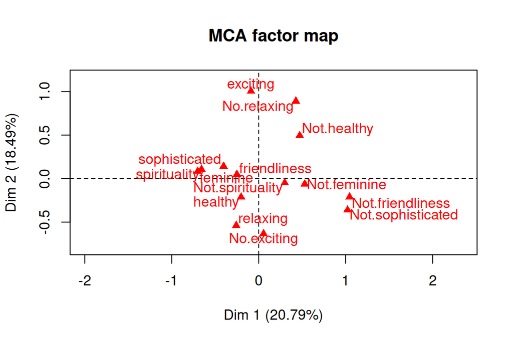

```r
# visualize MCA
plot(mca, invisible=c("ind"), graph.type = "classic")
```